# First Order Random Walk

Benjamin Christoffersen

2019-03-04

## Introduction

We will simulate and estimate a random walk model in this example using the particle filter and smoother. For details see this vignette which can also be found by calling `vignette("Particle_filtering", package = "dynamichazard")`. The models we are going to simulate from and estimate are of the form

$$\begin{split}
y_{it} &\sim g(\cdot\vert\eta_{it}) & \\
\vec{\eta}_t &= X_tR^+\vec{\alpha}_t \\
\vec{\alpha}_t &= F\vec{\alpha}_{t - 1} + R\vec{\epsilon}_t &
\quad \vec{\epsilon}_t \sim N(\vec{0}, Q) \\
& & \quad \vec{\alpha}_0 \sim N(\vec{a}_0, Q_0)
\end{split}, \qquad
\begin{array}{l} i = 1, \dots, n_t \\ t = 1, \dots, d \end{array}$$

where the $y_{it}$’s are binary event indicators for individual $i$ at time $t$. It is one if individual $i$ dies at in the time period $(t - 1, t]$.  
$X_t$ are covariates and $\vec{\alpha}_0,\dots,\vec{\alpha}_d$ are the latent states. The probability that $y_{it}$ is one conditional on no prior event ($y_{ij} = 0$ for $j = 0,\dots, t - 1$) is the inverse logit function of $\eta_{it}$. Thus, the model is related to a so-called conditional logistic regression. The difference is that we have a distributional assumption about the intercept and we allow some of the other coefficients to vary. The true values are

$$F = \begin{pmatrix}1 & 0 \\ 0 & 1 \end{pmatrix}, \quad
Q = \begin{pmatrix}0.33^2 & -3/4 \cdot .33^2 \\ -3/4 \cdot .33^2 & 0.33^2 \end{pmatrix}, \quad
R = I_2, \quad
\vec{\alpha} = (-6, -2)^\top$$

where $I_2$ is the two-dimensional identity matrix. The unknown parameters to be estimated is $Q$ and maybe $\vec{a}_0$. This example is run on the git branch “devel” with ID “789b7e9”. The code can be found on the github site for the package. All functions which assignments are not shown and are not in the `dynamichazard` package can be found on the github site.

## Simulation

We start by simulating the data. Feel free to skip this part as the specifications are given above. First we assign the parameters for the simulation

```r
n_obs     <- 1000L
n_periods <- 100L

Qmat <- matrix(c(.33^2, -.75 * .33^2, -.75 * .33^2, .33^2), 2)
a_0 <- c(-6, -2)
```

Then we simulate and plot the latent states

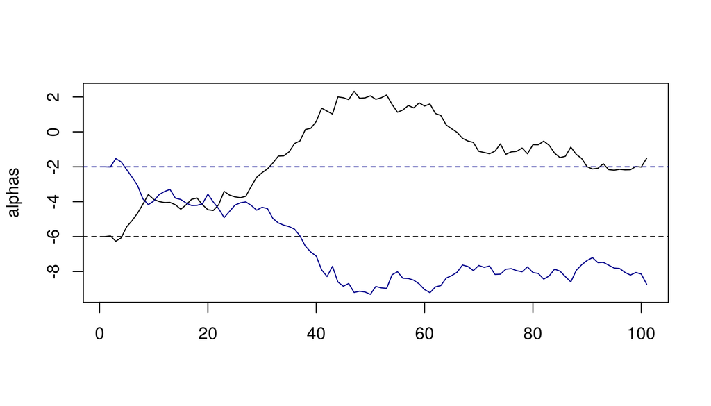

```r
set.seed(98734059)
alphas <- matrix(nrow = n_periods + 1, ncol = 2)
alphas[1, ] <- a_0
for(i in 1:n_periods + 1)
  alphas[i, ] <- alphas[i - 1, ] + drop(rnorm(2) %*% chol(Qmat))

# plot of latent variables
cols <- c("black", "darkblue")
matplot(alphas, type = "l", lty = 1, col = cols)
for(i in 1:2)
  abline(h = a_0[i], lty = 2, col = cols[i])
```

We simulate the observations as follows

```r
df <- replicate(n_obs, {
  # left-censoring
  tstart <- max(0L, sample.int((n_periods - 1L) * 2L, 1) - n_periods + 1L)

  # covariates
  x <- runif(1, 0, 2)
  covars <- c(1, x)

  # outcome (stop time and event indicator)
  y <- FALSE
  for(tstop in (tstart + 1L):n_periods){
    inv_logit <- 1 / (1 + exp(-covars %*% alphas[tstop + 1L, ]))
    if(inv_logit > runif(1)){
      y <- TRUE
      break
    }
  }

  c(tstart = tstart, tstop = tstop, x = x, y = y)
})
df <- data.frame(t(df))
head(df, 10)
```

```
##    tstart tstop      x y
## 1      11   100 1.5603 0
## 2      71   100 1.1283 0
## 3       0    36 0.6819 1
## 4       0   100 1.7753 0
## 5      21   100 0.7020 0
## 6       0   100 0.7128 0
## 7       0   100 1.3028 0
## 8       0   100 0.9445 0
## 9       0   100 1.2364 0
## 10      0   100 1.3548 0
```

We left-censor the observations since we otherwise may end up with a low number of observations towards the end.

### Model without latent variables

We can fit a model without the latent variables (i.e., a constant coefficient model) as follows

```r
library(dynamichazard)
stat_fit <- static_glm(
  Surv(tstart, tstop, y) ~ x, data = df, by = 1, max_T = n_periods,
  family = "logit")
summary(stat_fit)$coefficients
```

```
##             Estimate Std. Error z value   Pr(>|z|)
## (Intercept)   -2.310    0.08963  -25.78 1.621e-146
## x             -4.323    0.19656  -21.99 3.301e-107
```

```r
logLik(stat_fit)
```

```
## 'log Lik.' -1452 (df=2)
```

The estimated coefficients seems plausible when looking at the previous plot. Further, we can compare the log-likelihood with this models with the log-likelihood approximation we get from the particle filter in the next section.

## Particle filter and smoother

We start by using the particle filter and smoother from (Fearnhead, Wyncoll, and Tawn 2010)

```r
set.seed(26564868)
system.time(pf_fearn <- PF_EM(
  Surv(tstart, tstop, y) ~ x, df,
  Q_0 = diag(3^2, 2), Q = diag(1, 2),
  by = 1, type = "RW", model = "logit", max_T = n_periods,
  control = dd_ctrl))
```

```
## a_0 not supplied. IWLS estimates of static glm model is used for random walk models. Otherwise the values are zero
```

```
##    user  system elapsed
## 4644.21   61.39  818.81
```

`system.time` is used to show the computation time. The final estimates and true values are

```r
print_Q_est <- function(x)
  list(est      =      x$Q,  actual      =      Qmat,
       est_chol = chol(x$Q), actual_chol = chol(Qmat))
print_Q_est(pf_fearn)
```

```
## $est
##             (Intercept)       x
## (Intercept)      0.1960 -0.1846
## x               -0.1846  0.2028
##
## $actual
##          [,1]     [,2]
## [1,]  0.10890 -0.08168
## [2,] -0.08168  0.10890
##
## $est_chol
##             (Intercept)       x
## (Intercept)      0.4427 -0.4171
## x                0.0000  0.1699
##
## $actual_chol
##      [,1]    [,2]
## [1,] 0.33 -0.2475
## [2,] 0.00  0.2183
```

The effective sample size at each time point looks as follows

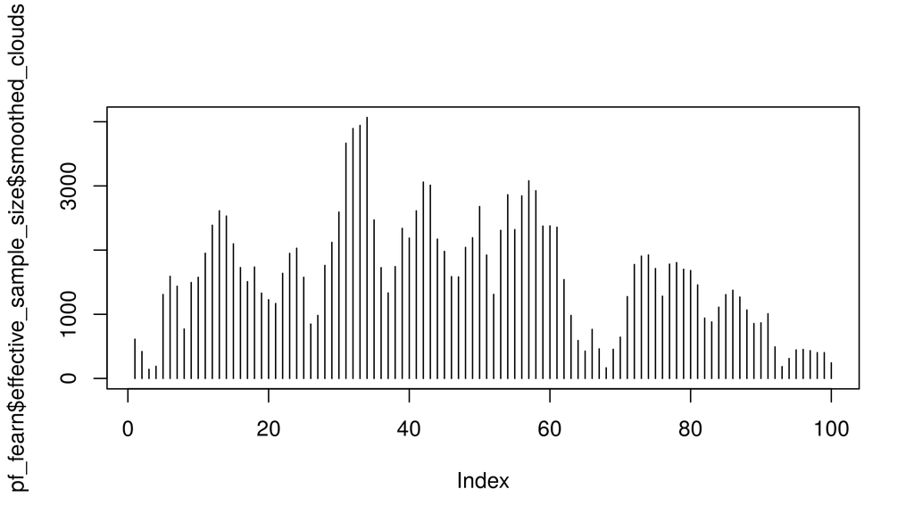

```r
plot(pf_fearn$effective_sample_size$smoothed_clouds, type = "h",
     ylim = range(0, pf_fearn$effective_sample_size$smoothed_clouds))
```

The approximate log-likelihoods at each EM iteration are

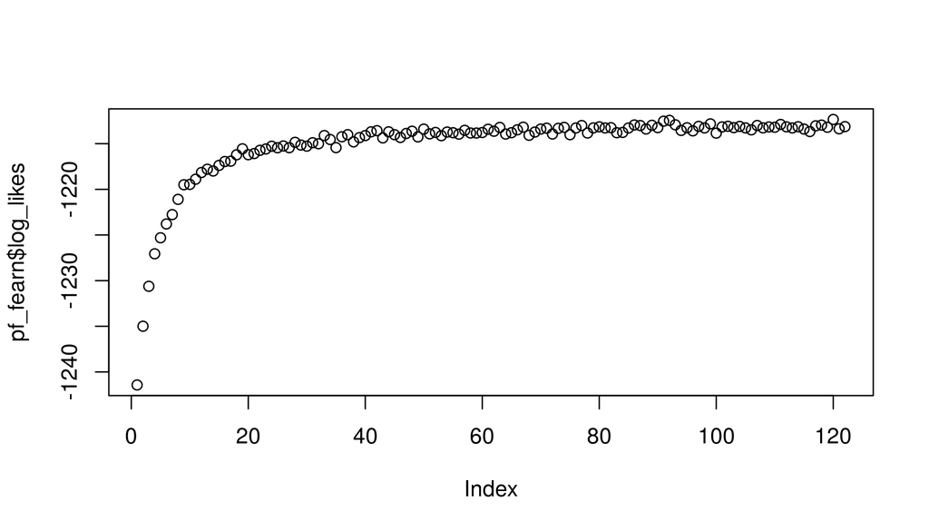

```r
plot(pf_fearn$log_likes)
```

We can plot the smoothed estimates as follows

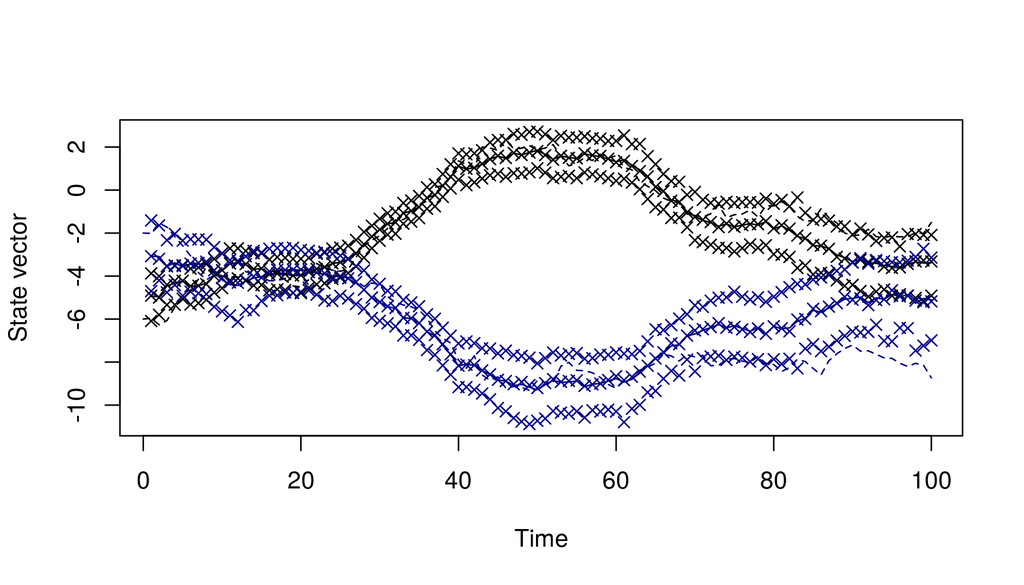

```r
plot(pf_fearn, qlvls = c(.05, .5, .95))
matplot(0:n_periods, alphas, type = "l", lty = 2, add = TRUE)
```

The crosses are the 5%, 50% and 95% (“pointwise”) quantiles estimates (due to the value we pass to `qlvls` argument of `plot.PF_EM`). The continuous lines are the smoothed mean estimates. The dashed lines are the true state variables.

The pointwise confidence bounds are broader toward the end. The cause may be that there are few events towards the end. E.g., there are the following number of events after time 70

```r
sum(df$y & df$tstop > 70)
```

```
## [1] 16
```

while there are quite a few who are still alive past time 70

```r
sum(df$tstop > 70)
```

```
## [1] 713
```

We can also estimate a model where we try to estimate $\vec{a}_0$ (though, I do not think we can expect to do this consistently)

```r
set.seed(26564868)
pf_fearn_w_a_0 <- PF_EM(
  Surv(tstart, tstop, y) ~ x, df,
  Q_0 = diag(3^2, 2), Q = diag(1, 2),
  by = 1, type = "RW", model = "logit", max_T = n_periods,
  control = dd_ctrl)
```

```
## a_0 not supplied. IWLS estimates of static glm model is used for random walk models. Otherwise the values are zero
```

The estimates are

```r
print_Q_est(pf_fearn_w_a_0)
```

```
## $est
##             (Intercept)       x
## (Intercept)      0.1960 -0.1846
## x               -0.1846  0.2028
##
## $actual
##          [,1]     [,2]
## [1,]  0.10890 -0.08168
## [2,] -0.08168  0.10890
##
## $est_chol
##             (Intercept)       x
## (Intercept)      0.4427 -0.4171
## x                0.0000  0.1699
##
## $actual_chol
##      [,1]    [,2]
## [1,] 0.33 -0.2475
## [2,] 0.00  0.2183
```

```r
pf_fearn_w_a_0$a_0
```

```
## (Intercept)           x
##      -2.310      -4.323
```

The approximate log-likelihoods at each EM iteration are

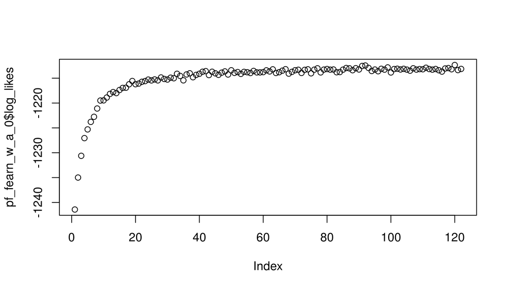

```r
plot(pf_fearn_w_a_0$log_likes)
```

We can plot the smoothed estimates like before

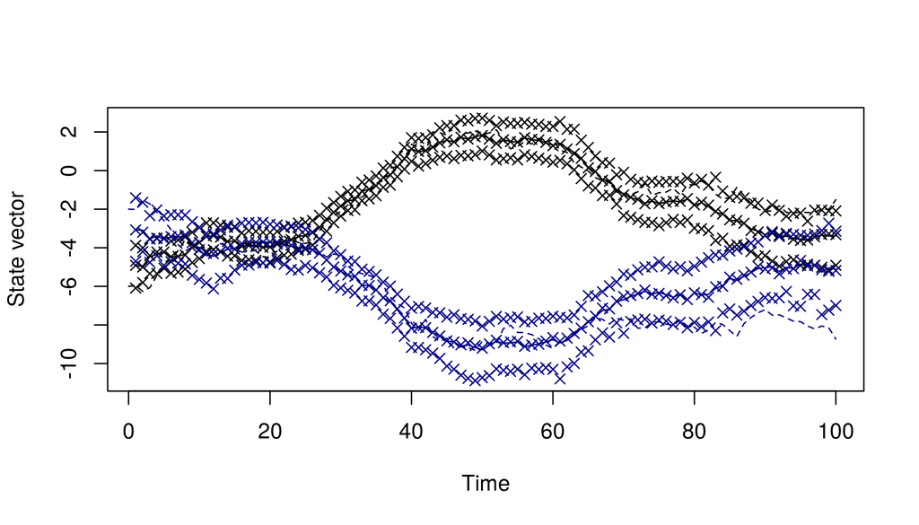

```r
plot(pf_fearn_w_a_0, qlvls = c(.05, .5, .95))
matplot(0:n_periods, alphas, type = "l", lty = 2, add = TRUE)
```

## Extended Kalman filter

We can compare the results above with the extended Kalman filter which is implemented in the package

```r
dd_fit <- ddhazard(
  Surv(tstart, tstop, y) ~ x, df, model = "logit", max_T = n_periods,
  Q_0 = diag(3^2, 2), Q = diag(1, 2), by = 1, order = 1,
  control = ddhazard_control(eps = .001, method = "EKF", NR_eps = 1e-4))
```

```
## a_0 not supplied. IWLS estimates of static glm model is used for random walk models. Otherwise the values are zero
```

The estimates are

```r
print_Q_est(dd_fit)
```

```
## $est
##             (Intercept)       x
## (Intercept)      0.1899 -0.2080
## x               -0.2080  0.3018
##
## $actual
##          [,1]     [,2]
## [1,]  0.10890 -0.08168
## [2,] -0.08168  0.10890
##
## $est_chol
##             (Intercept)       x
## (Intercept)      0.4357 -0.4774
## x                0.0000  0.2719
##
## $actual_chol
##      [,1]    [,2]
## [1,] 0.33 -0.2475
## [2,] 0.00  0.2183
```

```r
dd_fit$state_vecs[1, ]
```

```
## (Intercept)           x
##      -4.580      -2.879
```

The smoothed estimates looks as follows

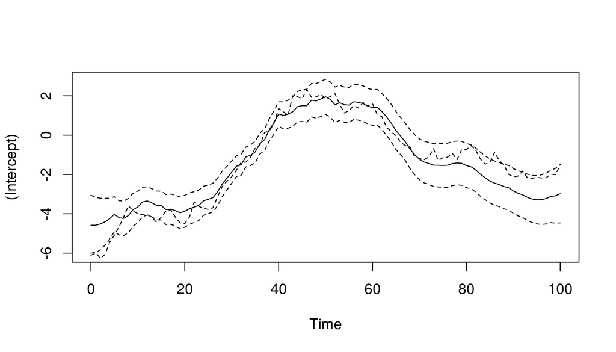

```r
plot(dd_fit, cov_index = 1, level = .9)
lines(0:n_periods, alphas[, 1], lty = 2)
```

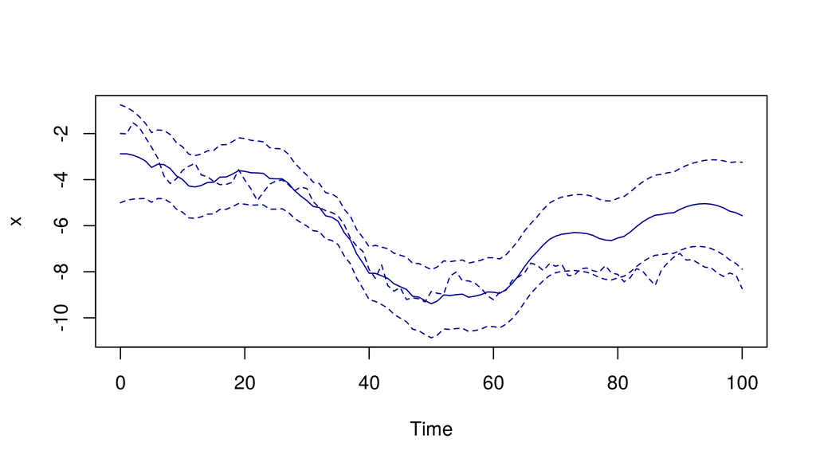

```r
plot(dd_fit, cov_index = 2, col = 2, level = .9)
lines(0:n_periods, alphas[, 2], lty = 2, col = 2)
```

Above, the “outer” dashed lines are 5% and 95% pointwise confidence bounds.

## References

Fearnhead, Paul, David Wyncoll, and Jonathan Tawn. 2010. “A Sequential Smoothing Algorithm with Linear Computational Cost.” *Biometrika* 97 (2). [Oxford University Press, Biometrika Trust]: 447–64. http://www.jstor.org/stable/25734097.